# Logistic Growth Part I

11/22/2021

## Meet the Squirlicorn (*Sciurus monocerus*})

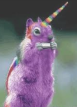

### *Natural History*

- Extremely territorial: Strictly ONE squirlicorn per oak tree.
- One colonist appears on Oakie Island, which contains \(K\) oak trees
- Reproduces asexually with some fixed probability \(p_b\) per year.
- Offspring disperses to nearest tree.
- If tree is occupied, existing squirlicorn assassinates newcomer with its horn.
- Is (of course) immortal.

## On Oakie Island: 64 trees and 0.2 offspring / year

## Some math

\[E(N_{t+1}) = N_t + b \, N_t \, T_a\] \(T_a\) = available trees, \(b\) - is birth rate.

Remember \(E()\) is *expectation* (NOT a variable … just a way to accept that we’re talking about random variables and are interested in their MEAN behavior … but we’ll drop it from here on out).

Key calculation: \[T_a = K - N_t\] \[N_{t+1} = N_t + b N_t(K - N_t)\] \[N_{t+1} - N_t = b N_t (K - N_t)\] Or - more generally with a death rate: \(\lambda = b - d\)

\[\Delta N_t = \lambda N_t (K - N_t)\]

Let’s just squeeze time to make this a differential equation:

\[{N_{t+\Delta t} - N_t \over \Delta t} = {r_b\over \Delta t} N_t (K - N_t)\] \[{dN \over dt} = r_0 N_t (K - N_t)\]

This is the **logistic population growth model**.

## Properties and Assumptions

The key assumption is that *growth rate* decreases *linearly* with *population*.

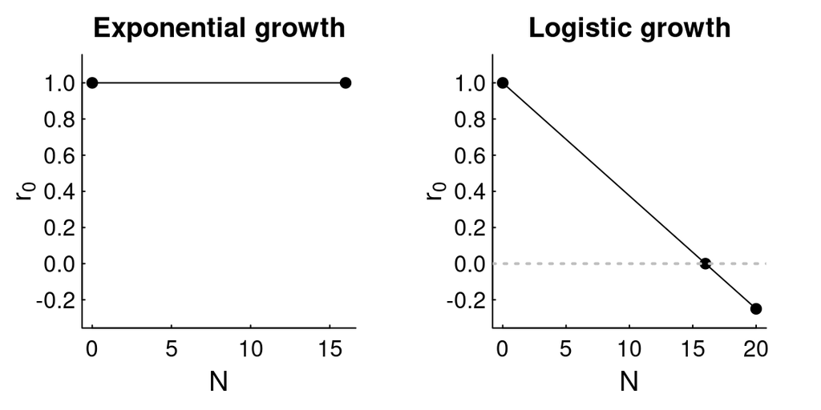

- At \(N = 0\) - growth = \(r_0\)
- At \(N = K\) - growth = \(0\)
- At \(N > K\) - growth < \(0\)

## Density Dependence

Any relationship where \(r\) or \(\lambda\) depends on \(N\) is called **Density Dependence**.

It does not *have* to be linear:

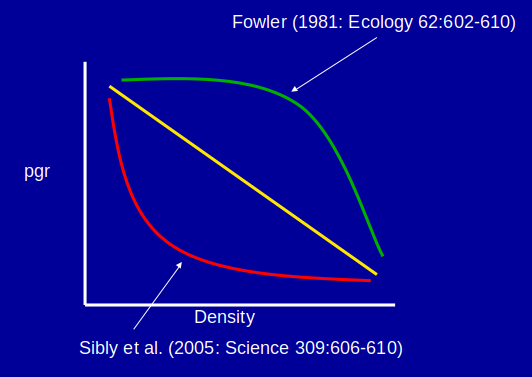

These different curves are different **forms** of density dependence.

Large Mammals: Density Dependence tends to kick in closer to carrying capacity.

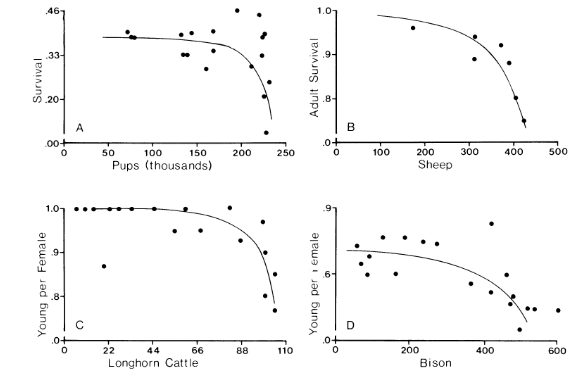

*Fowler, Charles W. “Density dependence as related to life history strategy.” Ecology 62.3 (1981): 602-610.*

## Other forms of Density Dependence

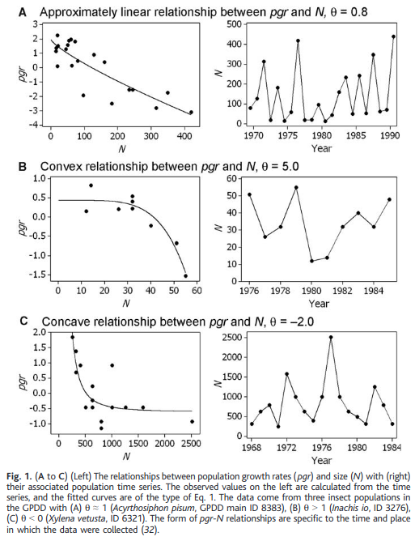

Sibly, Richard M., et al. “On the regulation of populations of mammals, birds, fish, and insects.” Science 309.5734 (2005): 607-610.

## Logistic Growth Curves

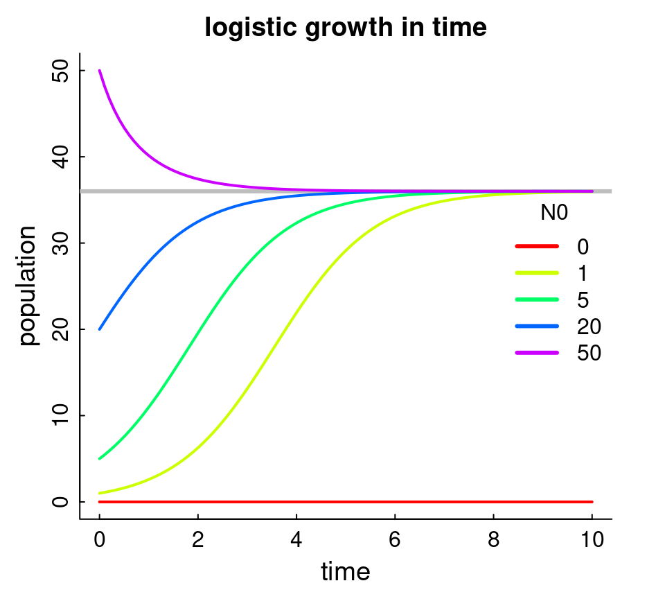

- Exponential growth at low \(N_0\), low values of time
- Typical “S” shape coming from below … Slows down at \(K\)
- Straight decay to \(K\) if \(N_0 > K\)